# Lab-4: Applied Statistical Modeling — Medical Insurance Costs

**Course:** Statistical Modeling with Python | **Dataset:** Option A — Medical Insurance Costs

This notebook covers Part 1 (EDA & Hypothesis Testing) and Part 2 (OLS Regression & Diagnostics). Part 3 (interactive dashboard) is implemented separately in `app.py` (Streamlit).

```python
import pandas as pd
import numpy as np
import matplotlib.pyplot as plt
import seaborn as sns
from scipy import stats
import statsmodels.api as sm
import statsmodels.formula.api as smf
from statsmodels.stats.outliers_influence import variance_inflation_factor
from statsmodels.stats.stattools import jarque_bera, omni_normtest

sns.set_style("whitegrid")
plt.rcParams["figure.figsize"] = (8, 5)

df = pd.read_csv("../data/insurance.csv")
df.head()
```

|  | age | sex | bmi | children | smoker | region | charges |
| --- | --- | --- | --- | --- | --- | --- | --- |
| 0 | 19 | female | 27.900 | 0 | yes | southwest | 16884.92400 |
| 1 | 18 | male | 33.770 | 1 | no | southeast | 1725.55230 |
| 2 | 28 | male | 33.000 | 3 | no | southeast | 4449.46200 |
| 3 | 33 | male | 22.705 | 0 | no | northwest | 21984.47061 |
| 4 | 32 | male | 28.880 | 0 | no | northwest | 3866.85520 |

## Part 1: Exploratory Data Analysis

```python
df.info()
```

```
<class 'pandas.DataFrame'>
RangeIndex: 1338 entries, 0 to 1337
Data columns (total 7 columns):
 #   Column    Non-Null Count  Dtype
---  ------    --------------  -----
 0   age       1338 non-null   int64
 1   sex       1338 non-null   str
 2   bmi       1338 non-null   float64
 3   children  1338 non-null   int64
 4   smoker    1338 non-null   str
 5   region    1338 non-null   str
 6   charges   1338 non-null   float64
dtypes: float64(2), int64(2), str(3)
memory usage: 94.5 KB
```

```python
print("Shape:", df.shape)
df.describe(include="all").T
```

```
Shape: (1338, 7)
```

|  | count | unique | top | freq | mean | std | min | 25% | 50% | 75% | max |
| --- | --- | --- | --- | --- | --- | --- | --- | --- | --- | --- | --- |
| age | 1338.0 | NaN | NaN | NaN | 39.207025 | 14.04996 | 18.0 | 27.0 | 39.0 | 51.0 | 64.0 |
| sex | 1338 | 2 | male | 676 | NaN | NaN | NaN | NaN | NaN | NaN | NaN |
| bmi | 1338.0 | NaN | NaN | NaN | 30.663397 | 6.098187 | 15.96 | 26.29625 | 30.4 | 34.69375 | 53.13 |
| children | 1338.0 | NaN | NaN | NaN | 1.094918 | 1.205493 | 0.0 | 0.0 | 1.0 | 2.0 | 5.0 |
| smoker | 1338 | 2 | no | 1064 | NaN | NaN | NaN | NaN | NaN | NaN | NaN |
| region | 1338 | 4 | southeast | 364 | NaN | NaN | NaN | NaN | NaN | NaN | NaN |
| charges | 1338.0 | NaN | NaN | NaN | 13270.422265 | 12110.011237 | 1121.8739 | 4740.28715 | 9382.033 | 16639.912515 | 63770.42801 |

### Descriptive metrics for numerical features (mean, median, std, IQR, skewness, kurtosis)

```python
num_cols = ["age", "bmi", "children", "charges"]
desc = pd.DataFrame({
    "mean": df[num_cols].mean(),
    "median": df[num_cols].median(),
    "std": df[num_cols].std(),
    "IQR": df[num_cols].quantile(0.75) - df[num_cols].quantile(0.25),
    "skewness": df[num_cols].skew(),
    "kurtosis": df[num_cols].kurt(),
})
desc
```

|  | mean | median | std | IQR | skewness | kurtosis |
| --- | --- | --- | --- | --- | --- | --- |
| age | 39.207025 | 39.000 | 14.049960 | 24.000000 | 0.055673 | -1.245088 |
| bmi | 30.663397 | 30.400 | 6.098187 | 8.397500 | 0.284047 | -0.050732 |
| children | 1.094918 | 1.000 | 1.205493 | 2.000000 | 0.938380 | 0.202454 |
| charges | 13270.422265 | 9382.033 | 12110.011237 | 11899.625365 | 1.515880 | 1.606299 |

**Observation:** `charges` is heavily right-skewed (skew ≈ 1.5+) with high kurtosis — a small number of high-cost patients (largely smokers) pull the distribution's tail out. `bmi` is close to normally distributed. `age` and `children` are more uniform/discrete.

### Distribution plots

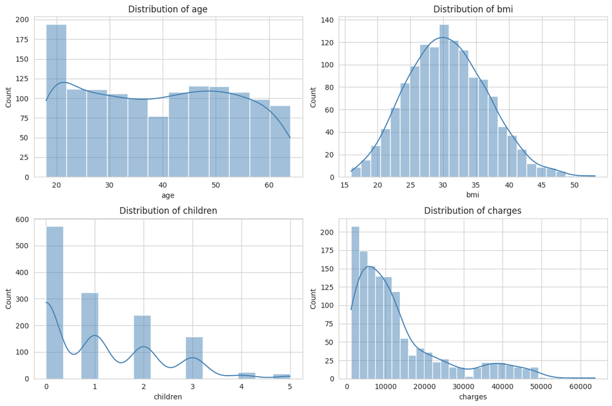

```python
fig, axes = plt.subplots(2, 2, figsize=(12, 8))
for ax, col in zip(axes.flat, num_cols):
    sns.histplot(df[col], kde=True, ax=ax, color="steelblue")
    ax.set_title(f"Distribution of {col}")
plt.tight_layout()
plt.savefig("../outputs_distributions.png", dpi=120)
plt.show()
```

### Bivariate relationships & correlation matrix

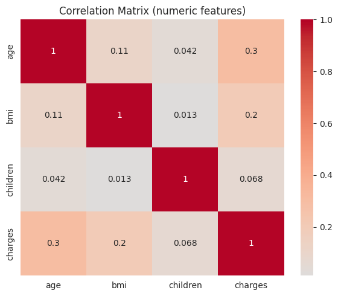

```python
fig, ax = plt.subplots(figsize=(6, 5))
sns.heatmap(df[num_cols].corr(), annot=True, cmap="coolwarm", center=0, ax=ax)
ax.set_title("Correlation Matrix (numeric features)")
plt.tight_layout()
plt.savefig("../outputs_corr.png", dpi=120)
plt.show()
```

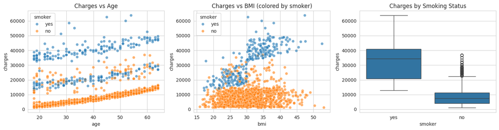

```python
fig, axes = plt.subplots(1, 3, figsize=(15, 4))
sns.scatterplot(data=df, x="age", y="charges", hue="smoker", ax=axes[0], alpha=0.6)
axes[0].set_title("Charges vs Age")
sns.scatterplot(data=df, x="bmi", y="charges", hue="smoker", ax=axes[1], alpha=0.6)
axes[1].set_title("Charges vs BMI (colored by smoker)")
sns.boxplot(data=df, x="smoker", y="charges", ax=axes[2])
axes[2].set_title("Charges by Smoking Status")
plt.tight_layout()
plt.savefig("../outputs_bivariate.png", dpi=120)
plt.show()
```

**Observation:** Smokers show a clear separate, much higher charges band. Among smokers, charges rise steeply with BMI — a strong candidate **interaction effect** (smoker × BMI) for the regression model in Part 2.

## Hypothesis Test 1 — Compare 2 Groups

**Groups:** Smokers vs. Non-Smokers | **Metric:** Medical Charges

- H0: There is no difference in mean/distribution of charges between smokers and non-smokers.
- H1: There is a significant difference in charges between smokers and non-smokers.

```python
smoker_charges = df.loc[df.smoker == "yes", "charges"]
nonsmoker_charges = df.loc[df.smoker == "no", "charges"]

# Normality check (Shapiro-Wilk)
sw_smoker = stats.shapiro(smoker_charges)
sw_nonsmoker = stats.shapiro(nonsmoker_charges)
print(f"Shapiro-Wilk (smokers):     stat={sw_smoker.statistic:.4f}, p={sw_smoker.pvalue:.4e}")
print(f"Shapiro-Wilk (non-smokers): stat={sw_nonsmoker.statistic:.4f}, p={sw_nonsmoker.pvalue:.4e}")

# Equal variance check (Levene's test)
levene_stat, levene_p = stats.levene(smoker_charges, nonsmoker_charges)
print(f"\nLevene's test: stat={levene_stat:.4f}, p={levene_p:.4e}")
```

```
Shapiro-Wilk (smokers):     stat=0.9396, p=3.6250e-09
Shapiro-Wilk (non-smokers): stat=0.8729, p=1.4459e-28

Levene's test: stat=332.6135, p=1.5593e-66
```

Both Shapiro-Wilk tests reject normality (p < 0.05 in each group), so the parametric t-test assumption is violated. We therefore use the **Mann-Whitney U test** (non-parametric) instead of a two-sample t-test.

```python
u_stat, u_p = stats.mannwhitneyu(smoker_charges, nonsmoker_charges, alternative="two-sided")
print(f"Mann-Whitney U test: U={u_stat:.1f}, p={u_p:.4e}")

alpha = 0.05
if u_p < alpha:
    print(f"\nConclusion (alpha={alpha}): Reject H0 — charges differ significantly between smokers and non-smokers.")
else:
    print(f"\nConclusion (alpha={alpha}): Fail to Reject H0 — no significant difference detected.")

print(f"\nMedian charges — Smokers: {smoker_charges.median():.2f} | Non-smokers: {nonsmoker_charges.median():.2f}")
```

```
Mann-Whitney U test: U=284133.0, p=5.2702e-130

Conclusion (alpha=0.05): Reject H0 — charges differ significantly between smokers and non-smokers.

Median charges — Smokers: 34456.35 | Non-smokers: 7345.41
```